# Sales Prediction and data exploration

```python
import pandas as pd  # used for working with dataframes
import warnings
warnings.filterwarnings("ignore")
import numpy as np # used for function on dataframes
import matplotlib.pyplot as plt # used for grpahing
import seaborn as sns # used to make graphs presentable
%matplotlib inline
from scipy import stats
import datetime
```

```python
test=pd.read_csv('test.csv')
train=pd.read_csv('sales_train.csv')
item_categories=pd.read_csv('item_categories.csv')
items=pd.read_csv('items.csv')
shops=pd.read_csv('shops.csv')
```

## **Data Dictionary**

### **Dependent Variable**

item_cnt_day **Numeric Variable** Amount of the specific item sold at the specific store on the given date

## **Independent Variables**

**date:** **Date-Time series** Represents the date the item was sold formated as dd/mm/yyyy  
**item_price:** **Numeric variable** current price of an item  
**date_block_num:** **Numeric variable** a consecutive month number, used for convenience. January 2013 is 0, February 2013 is 1,..., October 2015 is 33  
**item_name:** **Categorical variable** name of the item  
**shop_name:** **Categorical variable** name of the shop  
**item_category_name:** **Categorical variable** name of the Category items belong to.

## **Descriptive Variables**

**Shop ID:** Used to identify a specific shop  
**Item ID:** used to identify the item  
**item_category_id:** Used to identify the category that the item belongs to

# Data Exploration

## Data questions that we can visualize

1. What are the total sales per store per month
2. What are the total sales per item per month
3. What is the growth in total sales per store for each month
4. What is the highest grossing item (item with the highest sales i.e. price X Items sold) per store per month
5. What is the average sales per day of week and what is the std of sales per day(Monday-Sunday)
6. What is the distribution of item prices
7. What month has the most gross sales
8. What day has the most gross sales
9. What week has the gross most sales
10. What is the Most expense/ lest expensive item

# Question 1: What are the total sales per store per month

To answer this we must first group our data by month & store

We can do this using the groupby function in pandas and use the date_block_num column which is a int representation of the months (NOTE: the date_block_num column continue to count past 12 so we do not have to worry about grouping the same month from diffrent years together

Ok lets group the months & shops first and take a look at the data. Before we do this however we need to make a new column for sales so that when we group we can get the sales per store instead of a sum of item ids and item qty sold

```python
train['gross_sales']=train['item_price']*train['item_cnt_day']
```

Now lets do the grouping of the month and store to find gross sales per store per month

```python
Group_by_month=train.drop(['item_id','item_price','item_cnt_day'],axis=1)
Group_by_month=Group_by_month.groupby(['date_block_num','shop_id']).sum()
Group_by_month.head()
```

| date_block_num | shop_id | gross_sales |
| --- | --- | --- |
| 0 | 0 | 2966412.00 |
|  | 1 | 1527320.00 |
|  | 2 | 1085064.80 |
|  | 3 | 560585.01 |
|  | 4 | 1433666.00 |

Ok now let's visualize this on a graph

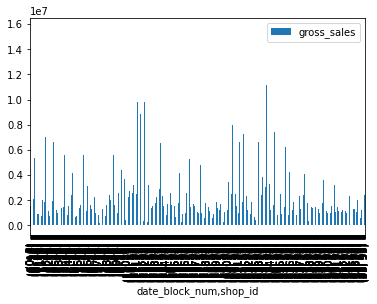

```python
Group_by_month.plot.bar();
```

Ok so while we now have a graph that shows exactlay what we want its not very presentable or useful for that matter.  
So to fix this we have a few diffrent options.  
We can try the following to make it more presentable or undertandable

1. bin the data into years instead of months
2. Take only 3 shops to graph per month
3. look at only one month specifically and compare sales

# 1-1. bin the data into years instead of months

```python
Group_by_month=train.drop(['item_id','item_price','item_cnt_day'],axis=1)
```

Ok to group by year intead of month lets create a dictionary and then apply that to the DF and then group by that to see sales per year per shop_id

```python
train['date_block_num'].unique() #This will show us how many months we have data on as we can see we do not have 3 full years
```

```
array([ 0,  1,  2,  3,  4,  5,  6,  7,  8,  9, 10, 11, 12, 13, 14, 15, 16,
       17, 18, 19, 20, 21, 22, 23, 24, 25, 26, 27, 28, 29, 30, 31, 32, 33],
      dtype=int64)
```

```python
year1=list(range(13))
year2=list(range(13,25))
year3=list(range(25,34))
Year_dict={'Year 1':year1,'Year 2':year2,'Year 3':year3} #create a dictionary with the Year value and the corresponding
#ints we want to assign the value in the DF
```

```python
Year_list=[]
for num in train['date_block_num']:
    for key, value in Year_dict.items():
        if num in value:
            Year_list.append(key)
```

```python
train['Years']=Year_list
train.head()
```

|  | date | date_block_num | shop_id | item_id | item_price | item_cnt_day | gross_sales | Years |
| --- | --- | --- | --- | --- | --- | --- | --- | --- |
| 0 | 02.01.2013 | 0 | 59 | 22154 | 999.00 | 1.0 | 999.00 | Year 1 |
| 1 | 03.01.2013 | 0 | 25 | 2552 | 899.00 | 1.0 | 899.00 | Year 1 |
| 2 | 05.01.2013 | 0 | 25 | 2552 | 899.00 | -1.0 | -899.00 | Year 1 |
| 3 | 06.01.2013 | 0 | 25 | 2554 | 1709.05 | 1.0 | 1709.05 | Year 1 |
| 4 | 15.01.2013 | 0 | 25 | 2555 | 1099.00 | 1.0 | 1099.00 | Year 1 |

```python
Group_by_month=train.drop(['item_id','item_price','item_cnt_day','date_block_num'],axis=1)
Group_by_month=Group_by_month.groupby(['Years','shop_id']).sum()
Group_by_month.head()
```

| Years | shop_id | gross_sales |
| --- | --- | --- |
| Year 1 | 0 | 6.637370e+06 |
|  | 1 | 3.238207e+06 |
|  | 2 | 1.417873e+07 |
|  | 3 | 9.537688e+06 |
|  | 4 | 1.732459e+07 |

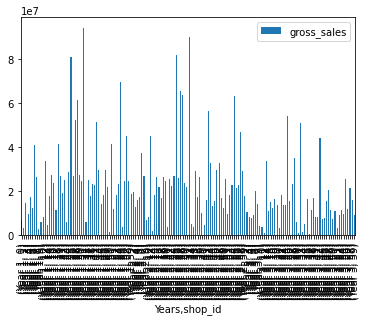

```python
Group_by_month.plot.bar();
```

Ok so this is better but we still cant really tell much of whats going on lets try to plot each year on a diffrent graph

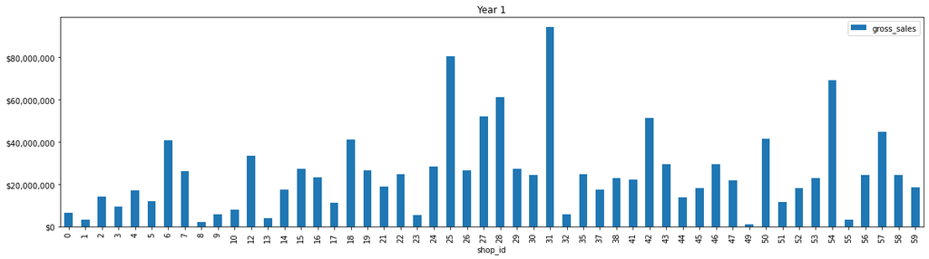

```python
import matplotlib.ticker as ticker
plt.rcParams['figure.figsize'] = [20, 5] #Changes the default size of the matplotlib output

fig, ax = plt.subplots(1, 1, figsize=(20, 5)) # choose fig size subplots


Group_by_month.xs('Year 1').plot(kind='bar',title='Year 1',ax=ax) #plot the first years sales
fmt = '${x:,.0f}' #Create the Regular expresion to cahnge y axes to $ with commas at the thousands place
tick = ticker.StrMethodFormatter(fmt) #set the format to tick
ax.yaxis.set_major_formatter(tick) #use the format as the format for the yaxis in the subplot ax
```

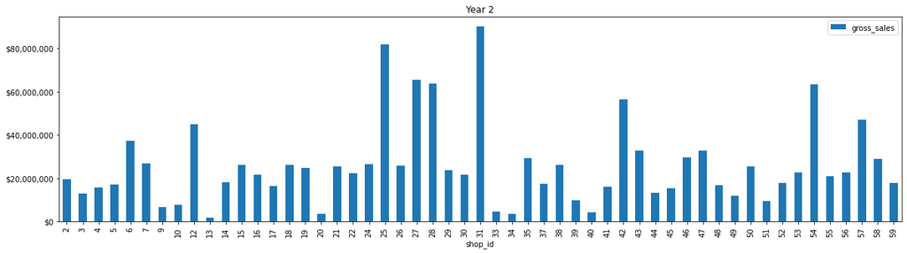

```python
fig, ax = plt.subplots(1, 1, figsize=(20, 5)) # choose fig size subplots


Group_by_month.xs('Year 2').plot(kind='bar',title='Year 2',ax=ax) #plot the first years sales
fmt = '${x:,.0f}' #Create the Regular expresion to cahnge y axes to $ with commas at the thousands place
tick = ticker.StrMethodFormatter(fmt) #set the format to tick
ax.yaxis.set_major_formatter(tick) #use the format as the format for the yaxis in the subplot ax
```

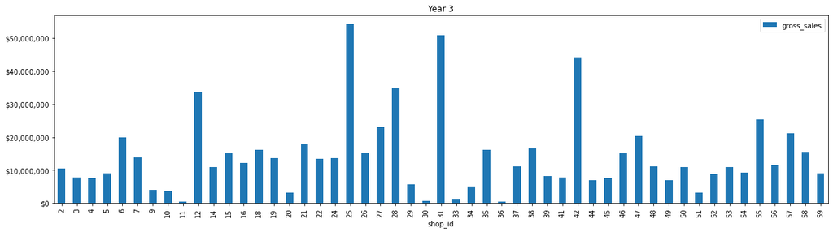

```python
fig, ax = plt.subplots(1, 1, figsize=(20, 5)) # choose fig size subplots


Group_by_month.xs('Year 3').plot(kind='bar',title='Year 3',ax=ax) #plot the first years sales
fmt = '${x:,.0f}' #Create the Regular expresion to cahnge y axes to $ with commas at the thousands place
tick = ticker.StrMethodFormatter(fmt) #set the format to tick
ax.yaxis.set_major_formatter(tick) #use the format as the format for the yaxis in the subplot ax
```

Ok this is intresting but it may be hard to compare to tell if sales are growing throughout our stores so lets try to plot Year 1 and Year 2 data on the same graph but use diffrent collors to show the diffrent years

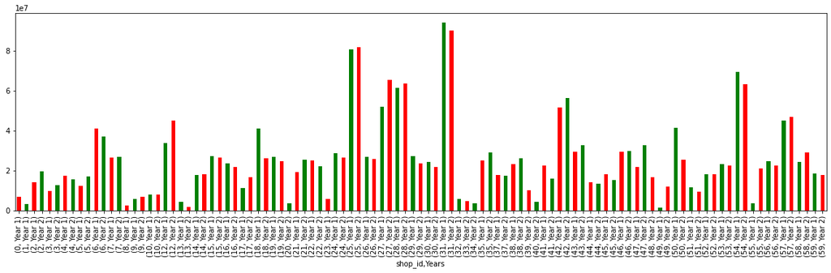

```python
train=train[(train['Years']=='Year 1') | (train['Years']=='Year 2')]
grf=train.groupby(['shop_id','Years'])['gross_sales'].sum()
grf.plot.bar(color=['red', 'green']);
```

As we can see not all stores made it to the next year this will need to be addresed so that we can accuretly use our color coding scheme and remove irrelvant data. Lets find the stores that did not have any data for year 2

```python
# use the following to find shops that have data in both year 2 and 1
groupby=train.groupby(['shop_id','Years']).sum()
groupby=groupby.reset_index() #resets the index so we can create array of shop IDs
shops=groupby['shop_id'] #creates array of shop IDs
(unique, counts) = np.unique(shops, return_counts=True) # counts the unique values in the serries creates array
frequencies = np.asarray((unique, counts)).T #creates the array using the count and unique values
frequencies=frequencies[np.logical_not(frequencies[:,1]==1)] #removes shops with only count 1 i.e. data in year 1 only
frequencies=frequencies[:,0] #selects only shop row
frequencies # these are the shops we want to plot in the above grpah
```

```
array([ 2,  3,  4,  5,  6,  7,  9, 10, 12, 13, 14, 15, 16, 17, 18, 19, 21,
       22, 24, 25, 26, 27, 28, 29, 30, 31, 35, 37, 38, 41, 42, 43, 44, 45,
       46, 47, 49, 50, 51, 52, 53, 54, 55, 56, 57, 58, 59], dtype=int64)
```

```python
print(len(frequencies))
```

```
47
```

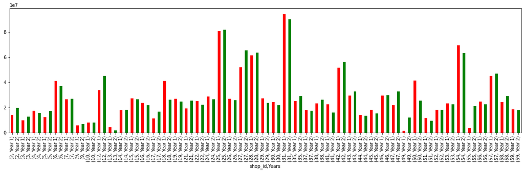

```python
shops_DF = pd.DataFrame({'shop_id':frequencies}) #turn array into df so we can merge
Merged_DF=pd.merge(groupby,shops_DF,how='inner',on='shop_id') #merge the data using inner so we drop the shops that
#we dont need
Merged_DF=Merged_DF.drop(['date_block_num','item_id','item_price','item_cnt_day'],axis=1)
grf=Merged_DF.groupby(['shop_id','Years'])['gross_sales'].sum()
grf.plot.bar(color=['red', 'green']);
```

```python
type(grf)
```

```
pandas.core.series.Series
```

OK this looks good now lets take a look at option 2 to only view a few stores by months

# 1-2. Take only three shops to graph per month

Ok lets take a look at the top 3 highest gross sales shops and view their sales per mont

```python
Groupby=train.groupby(['shop_id']).sum()
Groupby=Groupby.reset_index()
Groupby.head()
```

|  | shop_id | date_block_num | item_id | item_price | item_cnt_day | gross_sales |
| --- | --- | --- | --- | --- | --- | --- |
| 0 | 0 | 5064 | 104811661 | 5.553869e+06 | 11705.0 | 6.637370e+06 |
| 1 | 1 | 2984 | 60950373 | 2.926161e+06 | 6311.0 | 3.238207e+06 |
| 2 | 2 | 250785 | 164039867 | 2.667720e+07 | 23169.0 | 3.359746e+07 |
| 3 | 3 | 247020 | 179167262 | 1.940945e+07 | 22174.0 | 2.230990e+07 |
| 4 | 4 | 355118 | 282999515 | 2.861739e+07 | 36047.0 | 3.295509e+07 |

```python
Groupby.sort_values(by=['gross_sales'], inplace=True,ascending=False)
Groupby=Groupby.reset_index()
shopIDs=Groupby.loc[[0,1,2], ['shop_id', 'gross_sales']]
shopIDs=shopIDs['shop_id']
```

```python
shopIDs
```

```
0    31
1    25
2    54
Name: shop_id, dtype: int64
```

```python
Groupby=train.groupby(['date_block_num','shop_id']).sum()
Groupby=Groupby.reset_index()
Groupby=Groupby[Groupby['shop_id'].isin(shopIDs)]
Groupby=Groupby.drop(columns=['item_id','item_price','item_cnt_day'])
Groupby.head()
```

|  | date_block_num | shop_id | gross_sales |
| --- | --- | --- | --- |
| 20 | 0 | 25 | 5376478.13 |
| 26 | 0 | 31 | 6334218.71 |
| 42 | 0 | 54 | 6193833.58 |
| 66 | 1 | 25 | 5530463.20 |
| 72 | 1 | 31 | 7033617.00 |

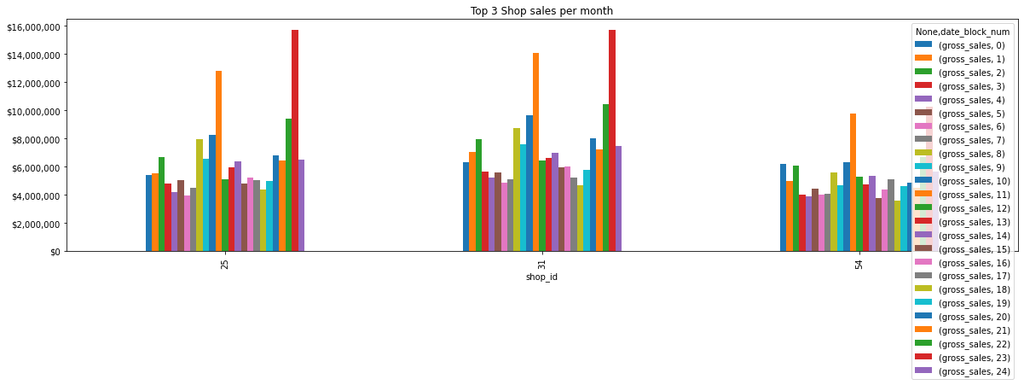

```python
fig, ax = plt.subplots(1, 1, figsize=(20, 5)) # choose fig size subplots

Groupby = Groupby.set_index(['shop_id', 'date_block_num'])
Groupby.unstack().plot(kind='bar',ax=ax,title='Top 3 Shop sales per month')
fmt = '${x:,.0f}' #Create the Regular expresion to cahnge y axes to $ with commas at the thousands place
tick = ticker.StrMethodFormatter(fmt) #set the format to tick
ax.yaxis.set_major_formatter(tick) #use the format as the format for the yaxis in the subplot ax
```

# 1-3 look at only one month specifically and compare sales for each shop

```python
groupby=train.groupby(['date_block_num','shop_id']).sum()
groupby.reset_index(inplace=True)
groupby=groupby[groupby['date_block_num']==24]
groupby=groupby.drop(columns=['item_id','item_price','item_cnt_day','date_block_num'])
groupby=groupby.set_index('shop_id')
groupby.sort_values(by=['gross_sales'], inplace=True)
```

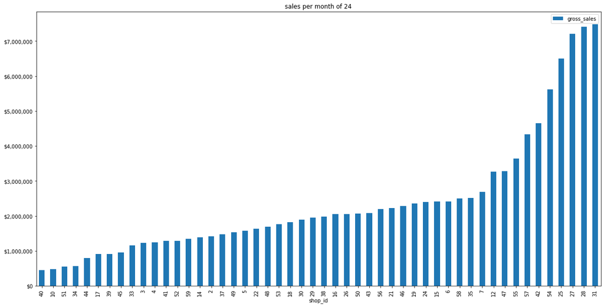

```python
fig, ax = plt.subplots(1, 1, figsize=(20, 10)) # choose fig size subplots

groupby.plot(kind='bar',ax=ax,title='sales per month of 24')
fmt = '${x:,.0f}' #Create the Regular expresion to cahnge y axes to $ with commas at the thousands place
tick = ticker.StrMethodFormatter(fmt) #set the format to tick
ax.yaxis.set_major_formatter(tick) #use the format as the format for the yaxis in the subplot ax
```

# Question 2: What are the total sales per item per month

For this if we try to graph each item for each month we will run into the same problem as beore when looking at sales per store per month so instead lets look at the sales per item category per year 1 and year 2

```python
len(train['item_id'].unique())
```

```
19244
```

```python
len(item_categories) #We have 84 item categories probably too much to graph for 2 years so lets do sales for each year in
#seprate graphs
```

```
84
```

```python
merged_DF=pd.merge(items,item_categories,on='item_category_id') #merge the item categories with the items Df
merged_DF=pd.merge(train,merged_DF,on='item_id')# merge the merged df with the train so we have the cateogires with the
#gross sales in one DF
```

```python
merged_DF.head()
```

|  | date | date_block_num | shop_id | item_id | item_price | item_cnt_day | gross_sales | Years | item_name | item_category_id | item_category_name |
| --- | --- | --- | --- | --- | --- | --- | --- | --- | --- | --- | --- |
| 0 | 02.01.2013 | 0 | 59 | 22154 | 999.0 | 1.0 | 999.0 | Year 1 | ЯВЛЕНИЕ 2012 (BD) | 37 | Кино - Blu-Ray |
| 1 | 23.01.2013 | 0 | 24 | 22154 | 999.0 | 1.0 | 999.0 | Year 1 | ЯВЛЕНИЕ 2012 (BD) | 37 | Кино - Blu-Ray |
| 2 | 20.01.2013 | 0 | 27 | 22154 | 999.0 | 1.0 | 999.0 | Year 1 | ЯВЛЕНИЕ 2012 (BD) | 37 | Кино - Blu-Ray |
| 3 | 02.01.2013 | 0 | 25 | 22154 | 999.0 | 1.0 | 999.0 | Year 1 | ЯВЛЕНИЕ 2012 (BD) | 37 | Кино - Blu-Ray |
| 4 | 03.01.2013 | 0 | 25 | 22154 | 999.0 | 1.0 | 999.0 | Year 1 | ЯВЛЕНИЕ 2012 (BD) | 37 | Кино - Blu-Ray |

```python
merged_DF=merged_DF.groupby(['item_category_name']).sum()
```

```python
merged_DF=merged_DF.reset_index()
```

```python
merged_DF=merged_DF[['item_category_name','gross_sales']]
merged_DF=merged_DF.set_index('item_category_name')
```

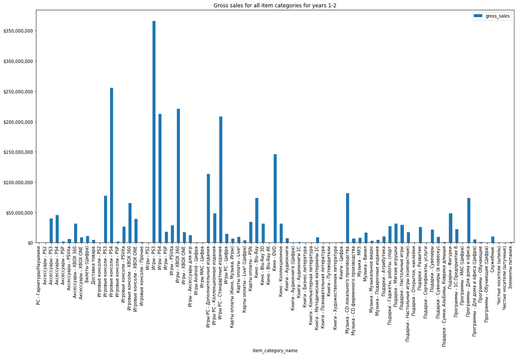

```python
fig, ax = plt.subplots(1, 1, figsize=(20, 10)) # choose fig size subplots

merged_DF.plot(kind='bar',ax=ax,title='Gross sales for all item categories for years 1-2')
fmt = '${x:,.0f}' #Create the Regular expresion to cahnge y axes to $ with commas at the thousands place
tick = ticker.StrMethodFormatter(fmt) #set the format to tick
ax.yaxis.set_major_formatter(tick) #use the format as the format for the yaxis in the subplot ax
```

A bit messy and some have very few sales if we want we can remove any items with less than $50,000,000 total in sales between years 1 and 2. This should make the graph more visable

```python
merged_DF_High_sales=merged_DF[merged_DF['gross_sales']>50000000]
merged_DF_High_sales.sort_values(by=['gross_sales'], inplace=True)
```

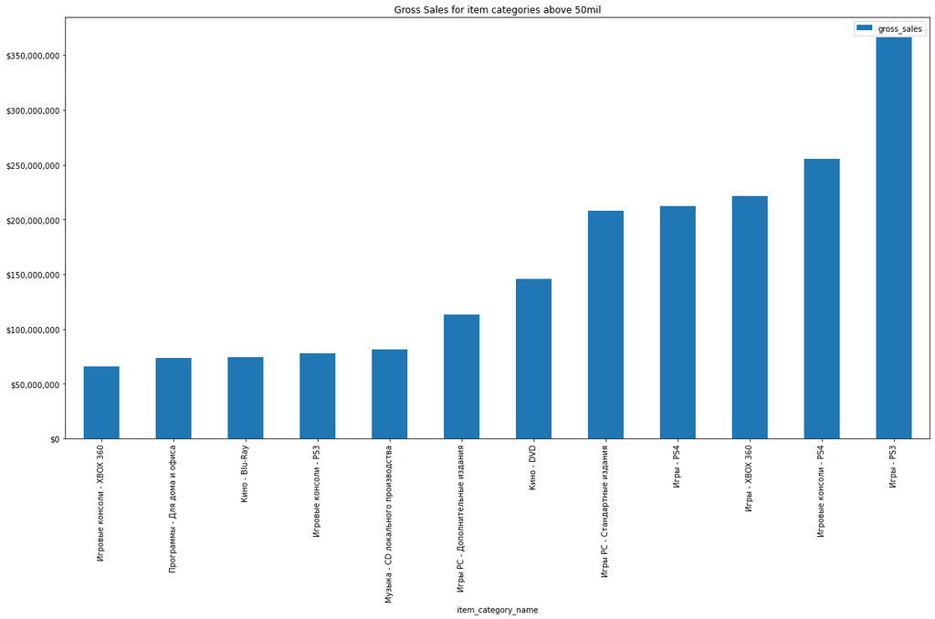

```python
fig, ax = plt.subplots(1, 1, figsize=(20, 10)) # choose fig size subplots

merged_DF_High_sales.plot(kind='bar',ax=ax,title='Gross Sales for item categories above 50mil')
fmt = '${x:,.0f}' #Create the Regular expresion to cahnge y axes to $ with commas at the thousands place
tick = ticker.StrMethodFormatter(fmt) #set the format to tick
ax.yaxis.set_major_formatter(tick) #use the format as the format for the yaxis in the subplot ax
```

from this we can make the ciritcal observation that it appears that the Play Station has won the console war in Russia

# Question 3: What is the growth in total sales per store for each month

Again for this question lets take 3 stores then graph their month to month sales growth using a simple plot

```python
Growth_DF=train.groupby(['date_block_num','shop_id']).sum()
Growth_DF=Growth_DF.reset_index()
shops=[25,31,54]
Growth_DF=Growth_DF.loc[Growth_DF['shop_id'].isin(shops)]

shop_25_DF=Growth_DF[Growth_DF['shop_id']==25]
shop_31_DF=Growth_DF[Growth_DF['shop_id']==31]
shop_54_DF=Growth_DF[Growth_DF['shop_id']==54]
```

```python
def Calc_growth(Sales_list):
    counter=0
    growth_list=[]
    for sales in Sales_list:
        if counter == 0:
            x=sales
            counter+=1
            continue
        growth=(sales/x)-1
        x=sales
        growth_list.append(growth)
        counter+=1
    return(growth_list)
```

```python
sales_25=shop_25_DF['gross_sales']
sales_31=shop_31_DF['gross_sales']
sales_54=shop_54_DF['gross_sales']
```

```python
sales_25_growth=Calc_growth(sales_25)
sales_31_growth=Calc_growth(sales_31)
sales_54_growth=Calc_growth(sales_54)
Growth_dict={'Store 25':sales_25_growth,'Store 31':sales_31_growth,'Store 54':sales_54_growth}
```

```python
Growth_DF=pd.DataFrame.from_dict(Growth_dict)
Growth_DF.head()
```

|  | Store 25 | Store 31 | Store 54 |
| --- | --- | --- | --- |
| 0 | 0.028641 | 0.110416 | -0.193569 |
| 1 | 0.203513 | 0.134244 | 0.212901 |
| 2 | -0.282942 | -0.295750 | -0.334160 |
| 3 | -0.125933 | -0.068991 | -0.035849 |
| 4 | 0.209984 | 0.063575 | 0.143906 |

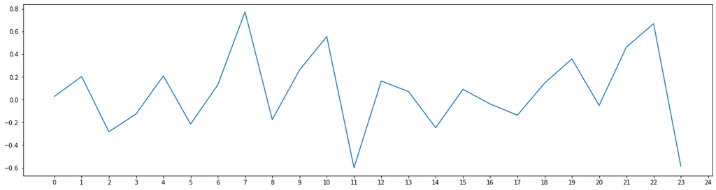

```python
fig = plt.figure()
ax = fig.add_axes([0.1, 0.1, 0.8, 0.8]) # main axes
ax.set_xticks(range(25))
ax.plot(Growth_DF['Store 25'])
```

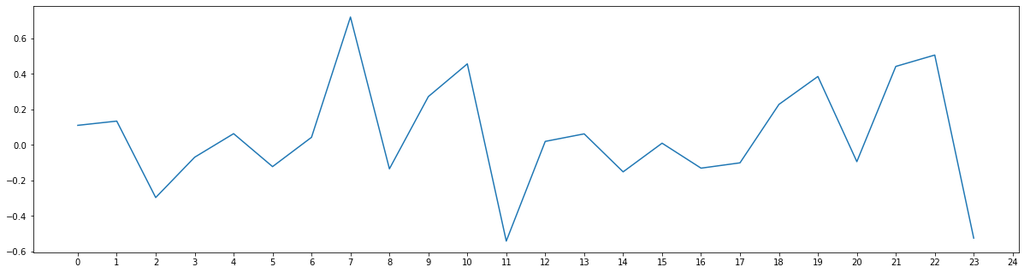

```python
fig = plt.figure()
ax = fig.add_axes([0.1, 0.1, 0.8, 0.8]) # main axes
ax.set_xticks(range(25))
ax.plot(Growth_DF['Store 31'])
```

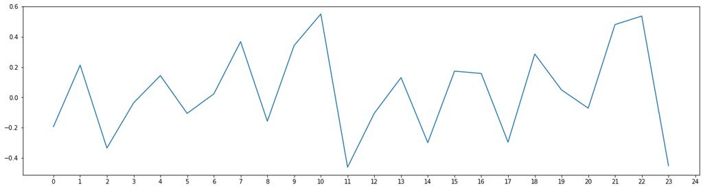

```python
fig = plt.figure()
ax = fig.add_axes([0.1, 0.1, 0.8, 0.8]) # main axes
ax.set_xticks(range(25))
ax.plot(Growth_DF['Store 54'])
```

From reviewing these graphs of the top 3 stores in terms of gross sales we can see that they have some similarties in their growth rates and cycles. For example months 10 and 7 seems to be peaks while month 11 seem to be the lowest growth relative to the last months sales across each of the stores

# Question 4: What is the highest grossing item (item with the highest sales i.e. price X Items sold) per store per month

```python
train.shape
```

```
(2411945, 8)
```

```python
merged_df=pd.merge(train,items,on='item_id')
```

```python
merged_df.shape # added the item names and item categories
```

```
(2411945, 10)
```

```python
merged_df.head()
```

|  | date | date_block_num | shop_id | item_id | item_price | item_cnt_day | gross_sales | Years | item_name | item_category_id |
| --- | --- | --- | --- | --- | --- | --- | --- | --- | --- | --- |
| 0 | 02.01.2013 | 0 | 59 | 22154 | 999.0 | 1.0 | 999.0 | Year 1 | ЯВЛЕНИЕ 2012 (BD) | 37 |
| 1 | 23.01.2013 | 0 | 24 | 22154 | 999.0 | 1.0 | 999.0 | Year 1 | ЯВЛЕНИЕ 2012 (BD) | 37 |
| 2 | 20.01.2013 | 0 | 27 | 22154 | 999.0 | 1.0 | 999.0 | Year 1 | ЯВЛЕНИЕ 2012 (BD) | 37 |
| 3 | 02.01.2013 | 0 | 25 | 22154 | 999.0 | 1.0 | 999.0 | Year 1 | ЯВЛЕНИЕ 2012 (BD) | 37 |
| 4 | 03.01.2013 | 0 | 25 | 22154 | 999.0 | 1.0 | 999.0 | Year 1 | ЯВЛЕНИЕ 2012 (BD) | 37 |

```python
merged_df=merged_df.groupby('item_name').sum() #sort by items and use sum functuion to get the sum of alll the gross sales
```

```python
merged_df=merged_df.reset_index() #re_index so we can pull itme name out of index
```

```python
merged_df.sort_values(by=['gross_sales'], inplace=True,ascending=False) #sort so we can see top 10 best selling items
```

```python
merged_df.head()
```

|  | item_name | date_block_num | shop_id | item_id | item_price | item_cnt_day | gross_sales | item_category_id |
| --- | --- | --- | --- | --- | --- | --- | --- | --- |
| 5736 | Sony PlayStation 4 (500 Gb) Black (CUH-1008A/1... | 73394 | 141002 | 29757150 | 9.588097e+07 | 9546.0 | 1.999917e+08 | 53496 |
| 3137 | Grand Theft Auto V [PS3, русские субтитры] | 77483 | 181567 | 21634404 | 1.526830e+07 | 15935.0 | 4.122266e+07 | 110143 |
| 11643 | Комплект Sony PS4 (500 Gb) Black (CUH-1108A/B0... | 18059 | 25311 | 10566198 | 1.954739e+07 | 1304.0 | 3.257515e+07 | 9432 |
| 3139 | Grand Theft Auto V [Xbox 360, русские субтитры] | 70071 | 165980 | 19189026 | 1.363547e+07 | 10981.0 | 2.867121e+07 | 118197 |
| 14544 | Одни из нас [PS3, русская версия] | 62651 | 161290 | 85798357 | 1.172803e+07 | 9054.0 | 2.160267e+07 | 97109 |

```python
Sorted_df=merged_df.iloc[0:10,[0,6]] #take the Item name and total sales for the top 10 items from the DF
```

```python
Sorted_df=Sorted_df.set_index('item_name')
```

```python
Sorted_df.head(10)
```

| item_name | gross_sales |
| --- | --- |
| Sony PlayStation 4 (500 Gb) Black (CUH-1008A/1108A/B01) | 1.999917e+08 |
| Grand Theft Auto V [PS3, русские субтитры] | 4.122266e+07 |
| Комплект Sony PS4 (500 Gb) Black (CUH-1108A/B01) + игра Grand Theft Auto V | 3.257515e+07 |
| Grand Theft Auto V [Xbox 360, русские субтитры] | 2.867121e+07 |
| Одни из нас [PS3, русская версия] | 2.160267e+07 |
| Grand Theft Auto V [PS4, русские субтитры] | 1.828801e+07 |
| Комплект "Microsoft Xbox One 500GB (Day One Edition Green Box)" + "FIFA 15" + "Forza Motorsport 5" | 1.704954e+07 |
| Diablo III [PC, Jewel, русская версия] | 1.616526e+07 |
| InFAMOUS: Второй сын [PS4, русская версия] | 1.393015e+07 |
| PS4: Контроллер игровой беспроводной черный (Dualshock 4 Cont Anthracite Black: CUH-ZCT1: SCEE) | 1.283106e+07 |

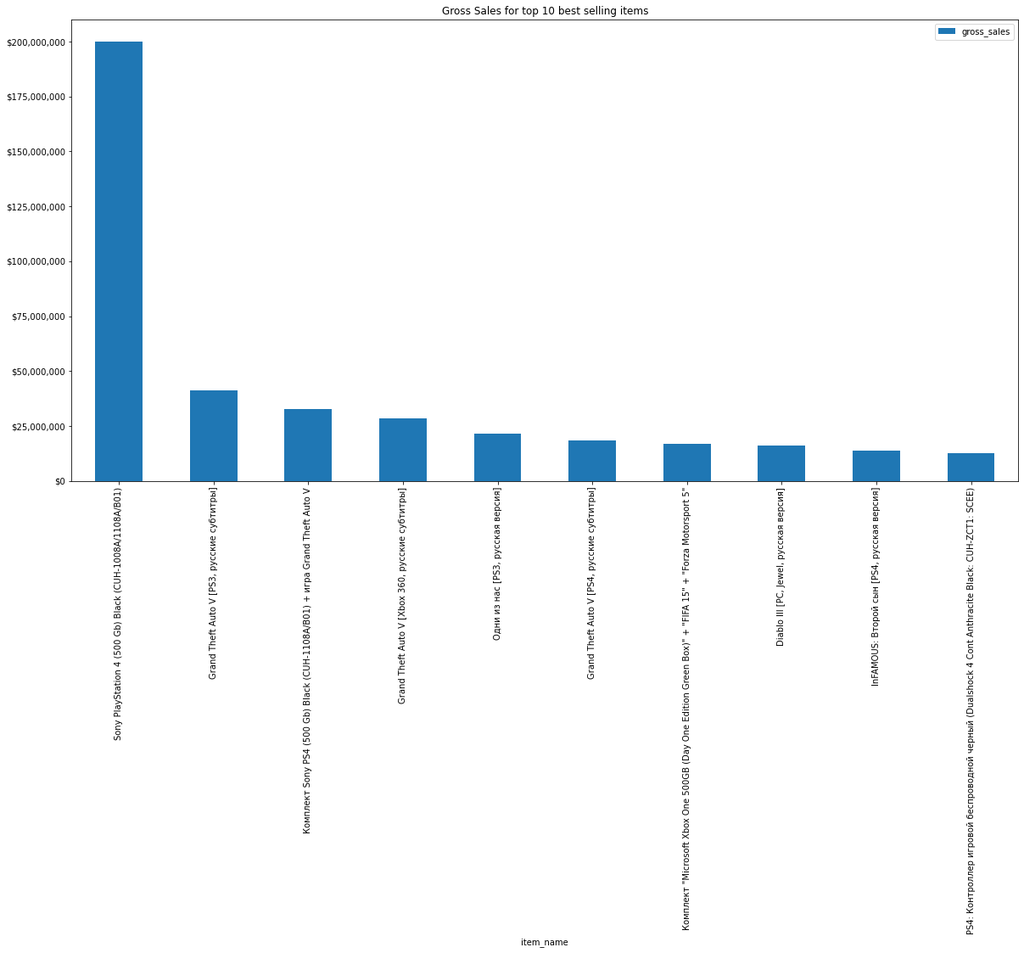

```python
fig, ax = plt.subplots(1, 1, figsize=(20, 10)) # choose fig size subplots

Sorted_df.plot(kind='bar',ax=ax,title='Gross Sales for top 10 best selling items')
fmt = '${x:,.0f}' #Create the Regular expresion to cahnge y axes to $ with commas at the thousands place
tick = ticker.StrMethodFormatter(fmt) #set the format to tick
ax.yaxis.set_major_formatter(tick) #use the format as the format for the yaxis in the subplot ax
```

# Question 5: What is the average sales per day of week and what is the std of sales per day(Monday-Sunday)

```python
train.head()
```

|  | date | date_block_num | shop_id | item_id | item_price | item_cnt_day | gross_sales | Years |
| --- | --- | --- | --- | --- | --- | --- | --- | --- |
| 0 | 02.01.2013 | 0 | 59 | 22154 | 999.00 | 1.0 | 999.00 | Year 1 |
| 1 | 03.01.2013 | 0 | 25 | 2552 | 899.00 | 1.0 | 899.00 | Year 1 |
| 2 | 05.01.2013 | 0 | 25 | 2552 | 899.00 | -1.0 | -899.00 | Year 1 |
| 3 | 06.01.2013 | 0 | 25 | 2554 | 1709.05 | 1.0 | 1709.05 | Year 1 |
| 4 | 15.01.2013 | 0 | 25 | 2555 | 1099.00 | 1.0 | 1099.00 | Year 1 |

```python
train['date']=pd.to_datetime(train['date']) #converts date column into date_series with format yyyy/mm/dd
```

```python
Sorted_DF=train.sort_values(by=['date']) #sort the date column from earliest date to latest date
```

```python
print(Sorted_DF.head(1)) #find the first day of info
print(Sorted_DF.tail(1)) #find the last day of info
```

```
            date  date_block_num  shop_id  item_id  item_price  item_cnt_day  \
21667 2013-01-01               0       28    18631       149.0           1.0

       gross_sales   Years
21667        149.0  Year 1
              date  date_block_num  shop_id  item_id  item_price  \
2350821 2015-12-01              24       22      482      3300.0

         item_cnt_day  gross_sales   Years
2350821           2.0       6600.0  Year 2
```

```python
Sorted_DF['Day_of_week']=Sorted_DF['date'].dt.dayofweek #creates column for day_of week with 0=Monday and 6=Sunday
```

```python
Sum_df=Sorted_DF.groupby('Day_of_week').sum()
Mean_df=Sorted_DF.groupby('Day_of_week').mean()
Std_df=Sorted_DF.groupby('Day_of_week').std()
```

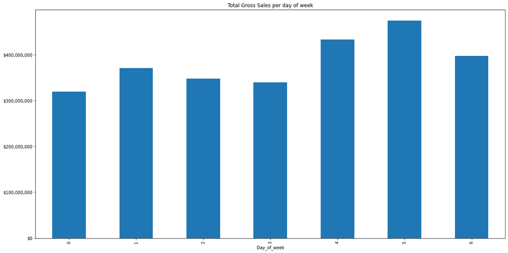

```python
fig, ax = plt.subplots(1, 1, figsize=(20, 10)) # choose fig size subplots

Sum_df['gross_sales'].plot(kind='bar',ax=ax,title='Total Gross Sales per day of week')
fmt = '${x:,.0f}' #Create the Regular expresion to cahnge y axes to $ with commas at the thousands place
tick = ticker.StrMethodFormatter(fmt) #set the format to tick
ax.yaxis.set_major_formatter(tick) #use the format as the format for the yaxis in the subplot ax
```

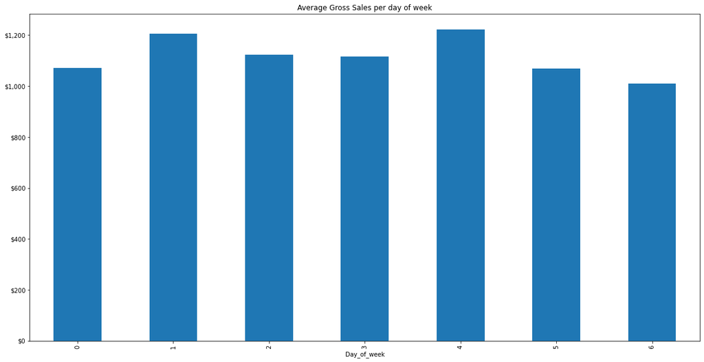

```python
fig, ax = plt.subplots(1, 1, figsize=(20, 10)) # choose fig size subplots

Mean_df['gross_sales'].plot(kind='bar',ax=ax,title='Average Gross Sales per day of week')
fmt = '${x:,.0f}' #Create the Regular expresion to cahnge y axes to $ with commas at the thousands place
tick = ticker.StrMethodFormatter(fmt) #set the format to tick
ax.yaxis.set_major_formatter(tick) #use the format as the format for the yaxis in the subplot ax
```

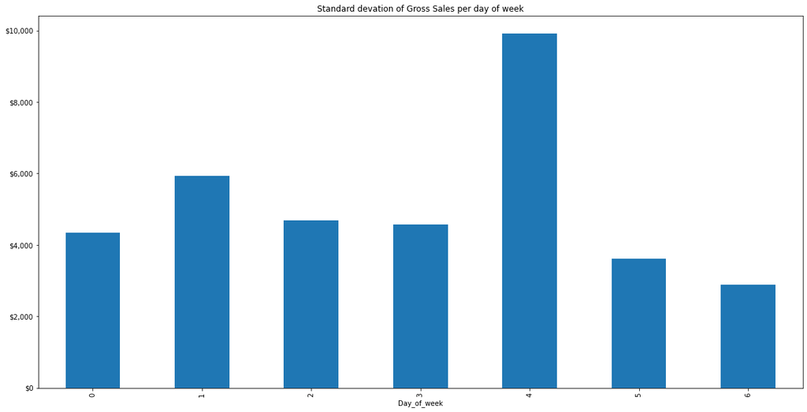

```python
fig, ax = plt.subplots(1, 1, figsize=(20, 10)) # choose fig size subplots

Std_df['gross_sales'].plot(kind='bar',ax=ax,title='Standard devation of Gross Sales per day of week')
fmt = '${x:,.0f}' #Create the Regular expresion to cahnge y axes to $ with commas at the thousands place
tick = ticker.StrMethodFormatter(fmt) #set the format to tick
ax.yaxis.set_major_formatter(tick) #use the format as the format for the yaxis in the subplot ax
```

Now lets take a look at the distibution of sales per day of week for each day of the week using a box plot

```python
Date_sorted=Sorted_DF.groupby('date').sum()
Date_sorted=Date_sorted.reset_index()
Date_sorted.head()
```

|  | date | date_block_num | shop_id | item_id | item_price | item_cnt_day | gross_sales | Day_of_week |
| --- | --- | --- | --- | --- | --- | --- | --- | --- |
| 0 | 2013-01-01 | 0 | 54436 | 17148075 | 1.211779e+06 | 1951.0 | 1362942.00 | 1669 |
| 1 | 2013-01-02 | 3356 | 94801 | 35875911 | 2.246770e+06 | 3817.0 | 2536633.00 | 6712 |
| 2 | 2013-01-03 | 6982 | 114697 | 35294914 | 2.330874e+06 | 3846.0 | 2518542.40 | 10473 |
| 3 | 2013-01-04 | 7014 | 76857 | 23471233 | 1.655931e+06 | 2574.0 | 1823273.00 | 9352 |
| 4 | 2013-01-05 | 17020 | 144233 | 44655126 | 2.478968e+06 | 4863.0 | 2727292.98 | 21275 |

```python
Date_sorted['Day_of_week']=Date_sorted['date'].dt.dayofweek
Date_sorted.head()
```

|  | date | date_block_num | shop_id | item_id | item_price | item_cnt_day | gross_sales | Day_of_week |
| --- | --- | --- | --- | --- | --- | --- | --- | --- |
| 0 | 2013-01-01 | 0 | 54436 | 17148075 | 1.211779e+06 | 1951.0 | 1362942.00 | 1 |
| 1 | 2013-01-02 | 3356 | 94801 | 35875911 | 2.246770e+06 | 3817.0 | 2536633.00 | 2 |
| 2 | 2013-01-03 | 6982 | 114697 | 35294914 | 2.330874e+06 | 3846.0 | 2518542.40 | 3 |
| 3 | 2013-01-04 | 7014 | 76857 | 23471233 | 1.655931e+06 | 2574.0 | 1823273.00 | 4 |
| 4 | 2013-01-05 | 17020 | 144233 | 44655126 | 2.478968e+06 | 4863.0 | 2727292.98 | 5 |

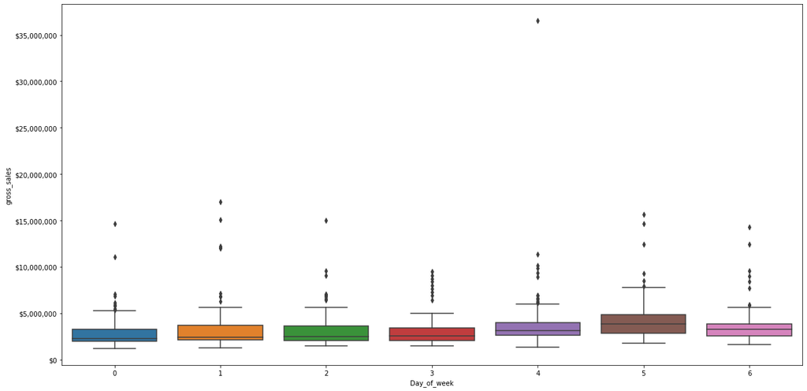

```python
y=Date_sorted['gross_sales']
x=Date_sorted['Day_of_week']

fig, ax = plt.subplots(1, 1, figsize=(20, 10)) # choose fig size subplots

sns.boxplot(x=x,y=y,ax=ax)
fmt = '${x:,.0f}' #Create the Regular expresion to cahnge y axes to $ with commas at the thousands place
tick = ticker.StrMethodFormatter(fmt) #set the format to tick
ax.yaxis.set_major_formatter(tick) #use the format as the format for the yaxis in the subplot ax
```

Wow look at those outliers one day in particular was indeed a good Friday with over 35 million in sales... While this is good news for the company this is bad news for us the datascientists lets go ahead and remove these outliers we will also remove any day with less than 10 in sales and try to run the box plots again

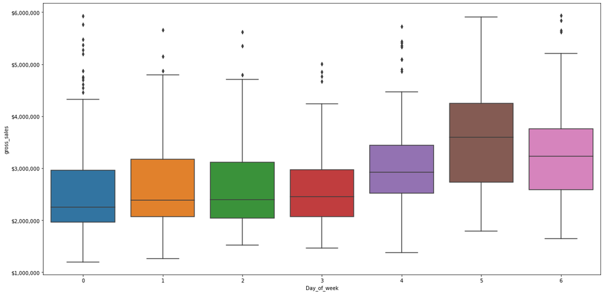

```python
New_sorted=Date_sorted[(Date_sorted['gross_sales']<6000000) & (Date_sorted['gross_sales']>10)]

y=New_sorted['gross_sales']
x=New_sorted['Day_of_week']

fig, ax = plt.subplots(1, 1, figsize=(20, 10)) # choose fig size subplots

sns.boxplot(x=x,y=y,ax=ax)
fmt = '${x:,.0f}' #Create the Regular expresion to cahnge y axes to $ with commas at the thousands place
tick = ticker.StrMethodFormatter(fmt) #set the format to tick
ax.yaxis.set_major_formatter(tick) #use the format as the format for the yaxis in the subplot ax
```

Now lets see the what item has the highest avergae amt sold per day of the week

```python
new_DF=pd.merge(train,items,on='item_id') #mereges so that we have 2 extra columns for item name and category on our train
#data fraame
```

```python
new_DF['Day_of_week']=new_DF['date'].dt.dayofweek
new_DF=new_DF.groupby(['Day_of_week','item_id']).mean()
new_DF=new_DF.reset_index()
new_DF=pd.merge(new_DF,items,on='item_id')
```

```python
Monday=new_DF[new_DF['Day_of_week']==0]
Monday=Monday[Monday['item_cnt_day']==Monday['item_cnt_day'].max()]
Monday=Monday[['item_name','item_cnt_day','Day_of_week']]

Tuesday=new_DF[new_DF['Day_of_week']==1]
Tuesday=Tuesday[Tuesday['item_cnt_day']==Tuesday['item_cnt_day'].max()]
Tuesday=Tuesday[['item_name','item_cnt_day','Day_of_week']]

Wednesday=new_DF[new_DF['Day_of_week']==2]
Wednesday=Wednesday[Wednesday['item_cnt_day']==Wednesday['item_cnt_day'].max()]
Wednesday=Wednesday[['item_name','item_cnt_day','Day_of_week']]

Thursday=new_DF[new_DF['Day_of_week']==3]
Thursday=Thursday[Thursday['item_cnt_day']==Thursday['item_cnt_day'].max()]
Thursday=Thursday[['item_name','item_cnt_day','Day_of_week']]

Friday=new_DF[new_DF['Day_of_week']==4]
Friday=Friday[Friday['item_cnt_day']==Friday['item_cnt_day'].max()]
Friday=Friday[['item_name','item_cnt_day','Day_of_week']]

Saturday=new_DF[new_DF['Day_of_week']==5]
Saturday=Saturday[Saturday['item_cnt_day']==Saturday['item_cnt_day'].max()]
Saturday=Saturday[['item_name','item_cnt_day','Day_of_week']]

Sunday=new_DF[new_DF['Day_of_week']==6]
Sunday=Sunday[Sunday['item_cnt_day']==Sunday['item_cnt_day'].max()]
Sunday=Sunday[['item_name','item_cnt_day','Day_of_week']]

Items_avg_per_day=pd.concat([Monday, Tuesday,Wednesday,Thursday,Friday,Saturday,Sunday])
Items_avg_per_day=Items_avg_per_day.set_index(['Day_of_week','item_name'])
Items_avg_per_day
```

| Day_of_week | item_name | item_cnt_day |
| --- | --- | --- |
| 0 | Свободный офис. Вып. 9 для Windows и Linux (box) (1 лиц.) | 49.000000 |
| 1 | Prototype 2 [PC, Цифровая версия] | 38.545455 |
| 2 | Средиземье: Тени Мордора [PC, Цифровая версия] | 188.000000 |
| 3 | Средиземье: Тени Мордора [PC, Цифровая версия] | 126.250000 |
| 4 | Средиземье: Тени Мордора. Premium Edition [PC, Цифровая версия] | 34.666667 |
| 5 | Ведьмак 3. Дикая охота. Комплект предварительного заказа [PS4, Xbox One, PC] | 66.000000 |
| 6 | Средиземье: Тени Мордора. Premium Edition [PC, Цифровая версия] | 44.666667 |

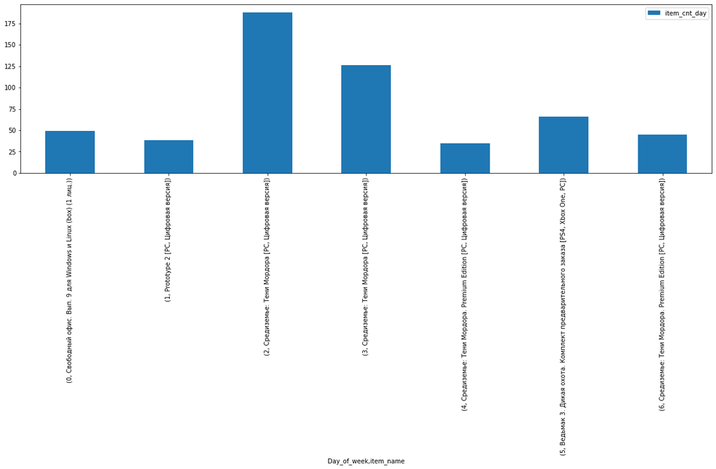

```python
Items_avg_per_day.plot.bar()
```

# Question 6: What is the distribution of item prices

```python
train.head()
```

|  | date | date_block_num | shop_id | item_id | item_price | item_cnt_day | gross_sales | Years |
| --- | --- | --- | --- | --- | --- | --- | --- | --- |
| 0 | 2013-02-01 | 0 | 59 | 22154 | 999.00 | 1.0 | 999.00 | Year 1 |
| 1 | 2013-03-01 | 0 | 25 | 2552 | 899.00 | 1.0 | 899.00 | Year 1 |
| 2 | 2013-05-01 | 0 | 25 | 2552 | 899.00 | -1.0 | -899.00 | Year 1 |
| 3 | 2013-06-01 | 0 | 25 | 2554 | 1709.05 | 1.0 | 1709.05 | Year 1 |
| 4 | 2013-01-15 | 0 | 25 | 2555 | 1099.00 | 1.0 | 1099.00 | Year 1 |

```python
item_ids=train['item_id']
prices=train['item_price']
```

```python
Items_dict= dict(zip(item_ids,prices)) #zips the two lists into a dic and removes duplicate key values i.e. the multiple item_ids
```

```python
item_prices = pd.DataFrame(list(Items_dict.items()),columns = ['Item_ID','Prices']) #Converts Dict to DF cannot use .from_dict
#because it is a sclar value i.e. each key has only one value not a list of values
```

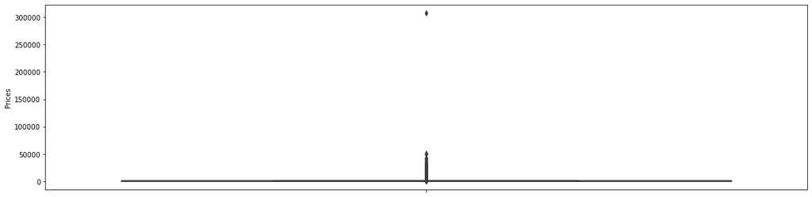

```python
sns.boxplot(item_prices['Prices'],orient = "v");
```

Uh oh looks like we have some major outliers some item costs upwards of 30,000 dollars lets remvoe these outlies then run the boxplot again

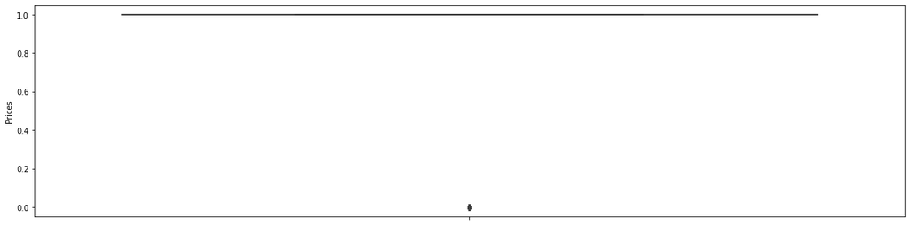

```python
sns.boxplot(item_prices['Prices']<10000,orient = "v");
```

[figure not shown]

```python
item_prices['Prices']=item_prices[(item_prices['Prices']<10000) & (item_prices['Prices']<10)]
sns.boxplot(item_prices['Prices'],orient = "v");
```

# Data Preparation

```python
test.head()
```

|  | ID | shop_id | item_id |
| --- | --- | --- | --- |
| 0 | 0 | 5 | 5037 |
| 1 | 1 | 5 | 5320 |
| 2 | 2 | 5 | 5233 |
| 3 | 3 | 5 | 5232 |
| 4 | 4 | 5 | 5268 |

```python
train.head()
```

[output not shown]

```python
train=pd.read_csv('sales_train.csv')
train.date=train.date.apply(lambda x:datetime.datetime.strptime(x, '%d.%m.%Y'))
train['month'] = pd.DatetimeIndex(train['date']).month
```

```python
train['gross_sales']=train['item_price']*train['item_cnt_day']
train.head()
```

|  | date | date_block_num | shop_id | item_id | item_price | item_cnt_day | month | gross_sales |
| --- | --- | --- | --- | --- | --- | --- | --- | --- |
| 0 | 2013-01-02 | 0 | 59 | 22154 | 999.00 | 1.0 | 1 | 999.00 |
| 1 | 2013-01-03 | 0 | 25 | 2552 | 899.00 | 1.0 | 1 | 899.00 |
| 2 | 2013-01-05 | 0 | 25 | 2552 | 899.00 | -1.0 | 1 | -899.00 |
| 3 | 2013-01-06 | 0 | 25 | 2554 | 1709.05 | 1.0 | 1 | 1709.05 |
| 4 | 2013-01-15 | 0 | 25 | 2555 | 1099.00 | 1.0 | 1 | 1099.00 |

```python
Monthly_sales=train.groupby(['date_block_num','shop_id','item_id']).agg({'gross_sales':'sum','month':'mean'})
Monthly_sales.head()
```

| date_block_num | shop_id | item_id | gross_sales | month |
| --- | --- | --- | --- | --- |
| 0 | 0 | 32 | 1326.0 | 1 |
|  |  | 33 | 1041.0 | 1 |
|  |  | 35 | 247.0 | 1 |
|  |  | 43 | 221.0 | 1 |
|  |  | 51 | 257.0 | 1 |

```python
Monthly_sales=Monthly_sales.reset_index()
Monthly_sales['date_block_num'].unique()
```

```
array([ 0,  1,  2,  3,  4,  5,  6,  7,  8,  9, 10, 11, 12, 13, 14, 15, 16,
       17, 18, 19, 20, 21, 22, 23, 24, 25, 26, 27, 28, 29, 30, 31, 32, 33],
      dtype=int64)
```

```python
Monthly_sales.head()
```

|  | date_block_num | shop_id | item_id | gross_sales | month |
| --- | --- | --- | --- | --- | --- |
| 0 | 0 | 0 | 32 | 1326.0 | 1 |
| 1 | 0 | 0 | 33 | 1041.0 | 1 |
| 2 | 0 | 0 | 35 | 247.0 | 1 |
| 3 | 0 | 0 | 43 | 221.0 | 1 |
| 4 | 0 | 0 | 51 | 257.0 | 1 |

## Converting categorical variables to strings and creating dummy varabiles for the model

We can leave the Date_Block_num as a numeric value because it is an ordinal variable and is already ordered as such, however we should convert all the ordinal columns into data type category

```python
months=Monthly_sales[['month']]
```

```python
months_dummy=pd.get_dummies(months,drop_first=False)
```

```python
months_dummy
```

|  | month |
| --- | --- |
| 0 | 1 |
| 1 | 1 |
| 2 | 1 |
| 3 | 1 |
| 4 | 1 |
| ... | ... |
| 1609119 | 10 |
| 1609120 | 10 |
| 1609121 | 10 |
| 1609122 | 10 |
| 1609123 | 10 |

1609124 rows × 1 columns

```python
Monthly_sales.info()
```

```
<class 'pandas.core.frame.DataFrame'>
RangeIndex: 1609124 entries, 0 to 1609123
Data columns (total 5 columns):
 #   Column          Non-Null Count    Dtype
---  ------          --------------    -----
 0   date_block_num  1609124 non-null  int64
 1   shop_id         1609124 non-null  int64
 2   item_id         1609124 non-null  int64
 3   gross_sales     1609124 non-null  float64
 4   month           1609124 non-null  int64
dtypes: float64(1), int64(4)
memory usage: 61.4 MB
```

```python
Monthly_sales=pd.concat([Monthly_sales,months_dummy],axis=1)
Monthly_sales.info()
```

```
<class 'pandas.core.frame.DataFrame'>
RangeIndex: 1609124 entries, 0 to 1609123
Data columns (total 6 columns):
 #   Column          Non-Null Count    Dtype
---  ------          --------------    -----
 0   date_block_num  1609124 non-null  int64
 1   shop_id         1609124 non-null  int64
 2   item_id         1609124 non-null  int64
 3   gross_sales     1609124 non-null  float64
 4   month           1609124 non-null  int64
 5   month           1609124 non-null  int64
dtypes: float64(1), int64(5)
memory usage: 73.7 MB
```

```python
Monthly_sales.drop('month',axis=1,inplace=True)
```

```python
import statsmodels.api as sm
import sklearn

x=Monthly_sales.drop(['gross_sales'],axis=1)
y=Monthly_sales[['gross_sales']]

from sklearn.linear_model import Ridge, Lasso
from sklearn.metrics import mean_squared_error,r2_score
from sklearn import linear_model
from sklearn.ensemble import GradientBoostingRegressor

priceridge= linear_model.Ridge()
priceridge.fit(x,y)


priceLasso= linear_model.Lasso()
priceLasso.fit(x,y)


priceGBR= GradientBoostingRegressor()
priceGBR.fit(x,y)
```

```
GradientBoostingRegressor()
```

# Evaluation of models

```python
from sklearn.model_selection import train_test_split
X_train, X_test, y_train, y_test = train_test_split(x, y, test_size=.20, random_state=0)
ridge=priceridge.predict(X_test)
lasso=priceLasso.predict(X_test)
GBR=priceGBR.predict(X_test)

print ('Ridge')
print (mean_squared_error(y_test, ridge)**.5)
print (r2_score(y_test, ridge))

print ('Lasso')
print (mean_squared_error(y_test, lasso)**.5)
print (r2_score(y_test, lasso))

print ('GBR')
print (mean_squared_error(y_test, GBR)**.5)
print (r2_score(y_test, GBR))
```

```
Ridge
14932.508575330601
0.0038016512804776026
Lasso
14932.508849652897
0.0038016146785335714
GBR
12642.246312082616
0.2859497641127621
```

```python
train.info()
```

```
<class 'pandas.core.frame.DataFrame'>
RangeIndex: 2935849 entries, 0 to 2935848
Data columns (total 8 columns):
 #   Column          Dtype
---  ------          -----
 0   date            datetime64[ns]
 1   date_block_num  int64
 2   shop_id         int64
 3   item_id         int64
 4   item_price      float64
 5   item_cnt_day    float64
 6   month           int64
 7   gross_sales     float64
dtypes: datetime64[ns](1), float64(3), int64(4)
memory usage: 179.2 MB
```

```python
group = train.groupby(['date_block_num','shop_id','item_id']).agg({'item_cnt_day': ['sum']})
#group.columns = ['item_cnt_month']
#group.reset_index(inplace=True)
```

```python
group.head()
```

| date_block_num | shop_id | item_id | item_cnt_day sum |
| --- | --- | --- | --- |
| 0 | 0 | 32 | 6.0 |
|  |  | 33 | 3.0 |
|  |  | 35 | 1.0 |
|  |  | 43 | 1.0 |
|  |  | 51 | 2.0 |